# team

Jonathan Kelly and Max Wisnieski

9/9/2020

```r
choco <- read.csv("https://raw.githubusercontent.com/xdaiISU/ds202materials/master/hwlabs/data/choco.csv")
str(choco)
```

```
## 'data.frame':    2312 obs. of  13 variables:
##  $ REF                 : int  2454 2458 2454 797 797 1015 1019 1011 1019 1011 ...
##  $ Company             : Factor w/ 541 levels "5150","A. Morin",..: 1 1 1 2 2 2 2 2 2 2 ...
##  $ Location            : Factor w/ 67 levels "Amsterdam","Argentina",..: 63 63 63 19 19 19 19 19 19 19 ...
##  $ Date                : int  2019 2019 2019 2012 2012 2013 2013 2013 2013 2013 ...
##  $ Bean_Origin         : Factor w/ 63 levels "Australia","Belize",..: 30 14 54 38 5 62 38 16 38 7 ...
##  $ Specific_Bean_Origin: Factor w/ 1436 levels "\"heirloom\", Arriba Nacional",..: 141 1435 666 1029 179 289 267 482 267 189 ...
##  $ Cocoa_Percent       : num  76 76 76 63 70 70 63 70 70 70 ...
##  $ Ingredients         : Factor w/ 21 levels "1- B","2- B,C",..: 5 5 5 10 10 10 5 10 10 10 ...
##  $ Characteristics1    : Factor w/ 450 levels "accesible","accessible",..: 81 81 311 131 430 272 403 328 81 240 ...
##  $ Characteristics2    : Factor w/ 502 levels "","\"Andes\" mint",..: 29 482 137 236 304 301 94 304 408 NA ...
##  $ Characteristics3    : Factor w/ 341 levels "","accessible",..: 115 260 29 251 NA 48 306 66 148 NA ...
##  $ Characteristics4    : Factor w/ 88 levels "acidic","apple",..: NA NA NA NA NA 66 NA 29 NA NA ...
##  $ Rating              : num  3.75 3.5 3.25 3.75 3.5 4 4 3.75 3.5 3.25 ...
```

## First Analysis

One analysis I wanted to look into was if there was any correlation between ingredients of the chocolate and its rating. I wanted to see if there were any ingredients that were more desirable, and if any were less desirable.

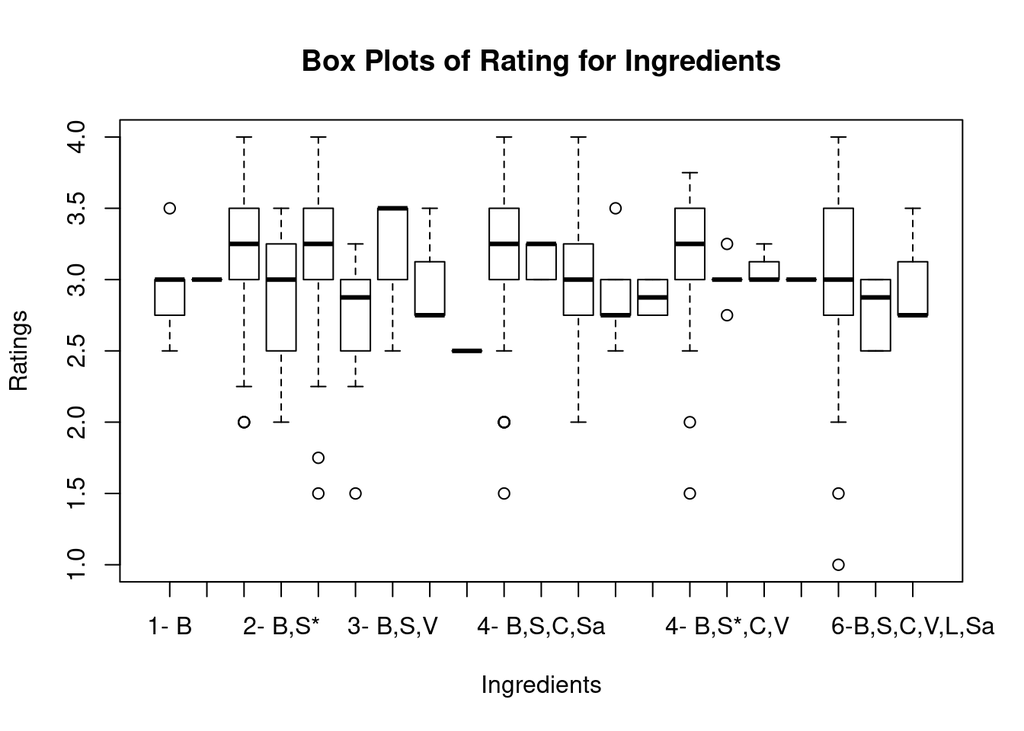

```r
rating <- choco$Rating
boxplot(rating~choco$Ingredients, main = "Box Plots of Rating for Ingredients", xlab = "Ingredients", ylab = "Ratings")
```

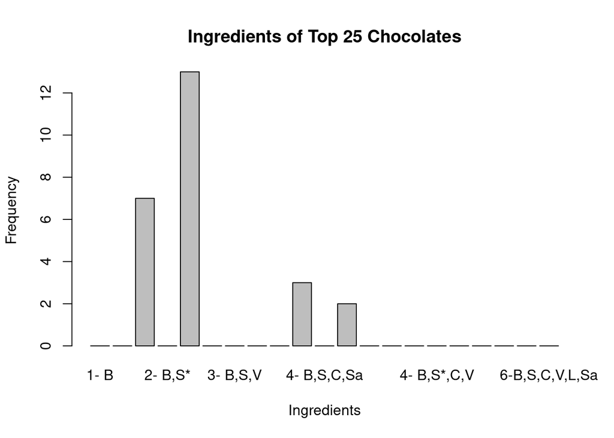

```r
ingrating <- choco[,c('Ingredients','Rating')]
ingorder <- ingrating[order(ingrating[,2], decreasing = TRUE),]
top <- head(ingorder, 25)
toptab <- table(top$Ingredients)
barplot(toptab, main = "Ingredients of Top 25 Chocolates", xlab = "Ingredients", ylab = "Frequency")
```

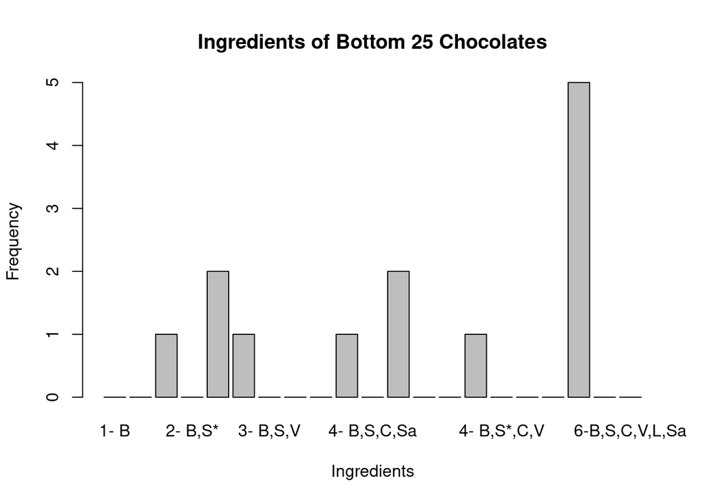

```r
bot <- tail(ingorder, 25)
bottab <- table(bot$Ingredients)
barplot(bottab, main = "Ingredients of Bottom 25 Chocolates", xlab = "Ingredients", ylab = "Frequency")
```

```r
ingredTop <- ingrating[ingrating$Ingredients == '3- B,S,C',]
summary(ingredTop)
```

```
##    Ingredients      Rating
##  3- B,S,C:885   Min.   :1.500
##  1- B    :  0   1st Qu.:3.000
##  2- B,C  :  0   Median :3.250
##  2- B,S  :  0   Mean   :3.275
##  2- B,S* :  0   3rd Qu.:3.500
##  (Other) :  0   Max.   :4.000
##  NA's    : 88   NA's   :88
```

```r
ingredTop2 <- ingrating[ingrating$Ingredients == '2- B,S',]
summary(ingredTop2)
```

```
##    Ingredients      Rating
##  2- B,S  :633   Min.   :2.000
##  1- B    :  0   1st Qu.:3.000
##  2- B,C  :  0   Median :3.250
##  2- B,S* :  0   Mean   :3.214
##  3- B,S,C:  0   3rd Qu.:3.500
##  (Other) :  0   Max.   :4.000
##  NA's    : 88   NA's   :88
```

```r
ingredBottom <- ingrating[ingrating$Ingredients == '5- B,S,C,V,L',]
summary(ingredBottom)
```

```
##        Ingredients      Rating
##  5- B,S,C,V,L:184   Min.   :1.00
##  1- B        :  0   1st Qu.:2.75
##  2- B,C      :  0   Median :3.00
##  2- B,S      :  0   Mean   :3.09
##  2- B,S*     :  0   3rd Qu.:3.50
##  (Other)     :  0   Max.   :4.00
##  NA's        : 88   NA's   :88
```

```r
ingredBottom2 <- ingrating[ingrating$Ingredients == '3- B,S,L',]
summary(ingredBottom2)
```

```
##    Ingredients     Rating
##  3- B,S,L: 8   Min.   :1.500
##  1- B    : 0   1st Qu.:2.625
##  2- B,C  : 0   Median :2.875
##  2- B,S  : 0   Mean   :2.688
##  2- B,S* : 0   3rd Qu.:3.000
##  (Other) : 0   Max.   :3.250
##  NA's    :88   NA's   :88
```

For my analysis I first looked at box plots for all of the ingredients, then looked at bar charts for the ingredients in the 25 highest and lowest rated chocolates. I then took some of the ingredients that were common on the top and bottom to do some summary statistics.

**Analysis:** From the box plots you can see that there isn’t a whole lot of deviation in ratings based on the ingredients. Next, looking at the bar charts it can be seen that ‘3-B,S,C’ is very common in the top 25 rated chocolates, while ‘5-B,S,C,V,L’ is very common in the bottom 25. Finally, looking at the summary statistics we can see that ‘3-B,S,C’ had an average rating of 3.275 and a max rating of 4.0, so it is very desirable to have in chocolate. However, ‘3-B,S,L’ has an average rating of 2.688 and a maximum of 3.25, so it is a poor choice for making chocolate.

## Analysis Two

The analysis I looked at was the difference the country of origin of the bean makes on percentage of cocoa that is in the chocolate, and what the geographical location of the top and lowest groups of countries are.

```r
cocoaOfBeanOriginCountry <- data.frame(choco$Bean_Origin, choco$Cocoa_Percent)
cocoaOfBeanOriginCountry <- aggregate(choco$Cocoa_Percent, by=list(beanOrigin=choco$Bean_Origin), FUN=mean)
cocoaOfBeanOriginCountry <- cocoaOfBeanOriginCountry[order(cocoaOfBeanOriginCountry$x),]
cocoaOfBeanOriginCountry
```

```
##               beanOrigin        x
## 32            Martinique 42.00000
## 56                Tobago 65.00000
## 50              Sulawesi 66.00000
## 15              DR Congo 68.00000
## 35               Nigeria 68.33333
## 41           Puerto Rico 68.33333
## 25                 India 68.66667
## 1              Australia 69.00000
## 59                U.S.A. 69.16667
## 9               Cameroon 69.33333
## 21               Grenada 69.36842
## 6                 Bolvia 70.00000
## 8                  Burma 70.00000
## 51               Sumatra 70.00000
```

[output cut: 49 more lines]

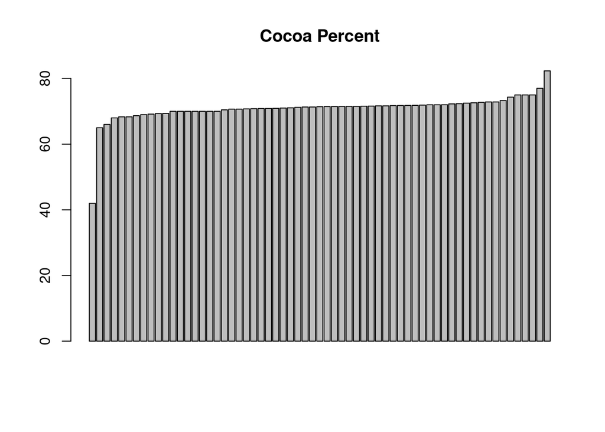

```r
attach(cocoaOfBeanOriginCountry)
barplot(main = "Cocoa Percent",  x)
```

```r
lowest15 <- head(cocoaOfBeanOriginCountry, n=15)
attach(lowest15)
```

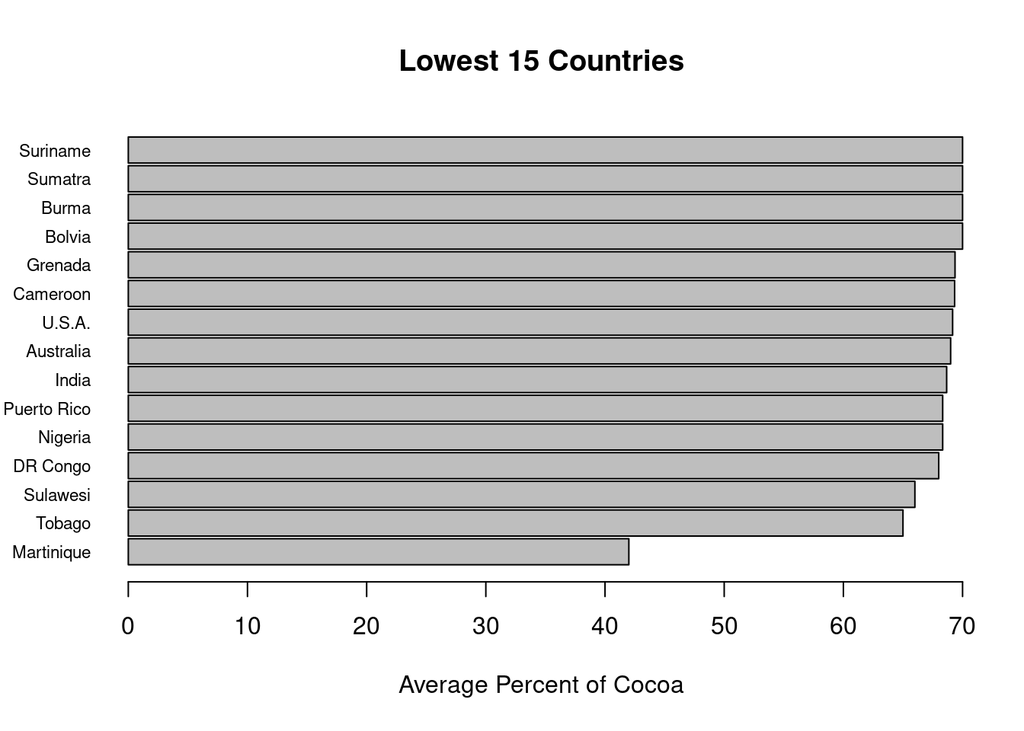

```r
barplot(main = "Lowest 15 Countries", xlab = "Average Percent of Cocoa", x, names.arg = beanOrigin,  horiz = TRUE, cex.names=0.7, las=1, space=0.1)
```

```r
best15 <- tail(cocoaOfBeanOriginCountry, n=15)
attach(best15)
```

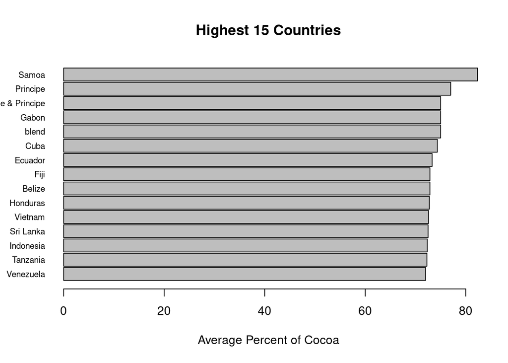

```r
barplot(main = "Highest 15 Countries", xlab = "Average Percent of Cocoa", x, names.arg = beanOrigin,  horiz = TRUE, cex.names=0.7, las=1, space=0.1)
```

Overall though most of the beans have roughly the same percentage of cocoa, around 68-75 percent, But with Martinique and Samoa being notable outliers at 42% and 82% respectfully.